# Dotted duckweed maxent study: Preliminary model run (rmd file #1)

### Perform spatial thinning to reduce spatial autocorrelation

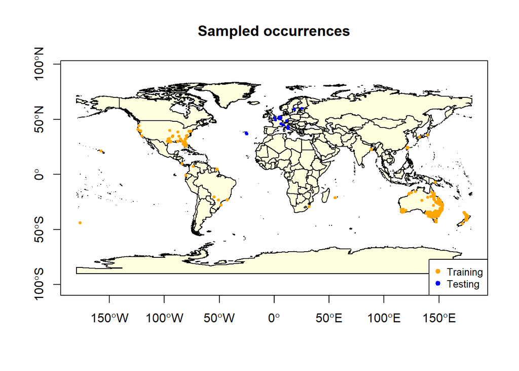

```r
set.seed(2018)
### To reduce sampling bias (disproportional reporting in some areas), a single observation was sampled
# by first creating a raster layer with the same extent as my environmental data
r <- raster(world)
# set resolution of cells (increased resolution enough to obtain ~30 observations)
res(r) <- 0.026
# sample 1 observation per area
world_sampled <- gridSample(world, r, n=1)

r <- raster(europe)
res(r) <- 0.026
europe_sampled <- gridSample(europe, r, n=1)

r <- raster(europe_sure)
res(r) <- 0.026
europe_sure_sampled <- gridSample(europe_sure, r, n=1)

world_sampled <- as.data.frame(world_sampled)
europe_sampled <- as.data.frame(europe_sampled)
europe_sure_sampled <- as.data.frame(europe_sure_sampled)

plot(wrld_simpl, axes=TRUE, col="light yellow", main = "Sampled occurrences")
legend("bottomright", legend=c("Training", "Testing"),
       col=c("orange", "blue"), cex=0.8, pch = 19)
# add observation points
points(world_sampled$lon, world_sampled$lat, col='orange', pch=20, cex=0.75)
points(europe_sampled$lon, europe_sampled$lat, col='blue', pch=20, cex=0.75)
```

### Divide dataset into training (world excluding Europe) and testing (Europe)

```r
pres_train <- world_sampled
pres_test <- europe_sampled
pres_test_sure <- europe_sure_sampled
write.csv(pres_train,"pres_train.csv",row.names=FALSE)
write.csv(pres_test,"pres_test.csv",row.names=FALSE)
write.csv(pres_test_sure,"pres_test_sure.csv",row.names=FALSE)
```

### Initial selection of bioclimatic variables

- To reflect thermal dependency of duckweeds in terms of population growth:

BIO 1 = Mean annual temperature (Armitage, 2022)

BIO 7 = Annual range of temperature (Armitage, 2022)

BIO 10 = Mean temperature of warmest quarter

- To account for the dependency on precipitation (duckweeds are rare in places with high or very low precipitation; FNA, 2000):

BIO17 = Precipitation of Driest Quarter

BIO19 = Annual precipitation

### Load lake water temperature raster

```r
#source for lake water temperature raster: https://onlinelibrary.wiley.com/doi/full/10.1111/ecog.06595#bib-0003
envs_lake <- raster::brick('bioclim_lakes_10km.tif')
```

### Subset raster to correspond to the pre-selected bioclimatic variables

```r
envs = envs_lake[[c(1,7,10,17,19)]] # pre-select bioclimatic variables
```

### Increase spatial resolution to correspond to resolution previously applied to raster of observation records

```r
envs <- disaggregate(envs, fact=3.2) # adjust resolution to correspond to resolution used to sample observations
```

### Crop environment to correspond to species distribution range

```r
full_dataset <- rbind(pres_train,pres_test)
model.extent<-extent(min(full_dataset$lon)-10,max(full_dataset$lon)+10,
                     min(full_dataset$lat)-10,max(full_dataset$lat)+10)
modelEnv <- crop(envs,model.extent)
```

### Create buffer around occurrence area and create study area

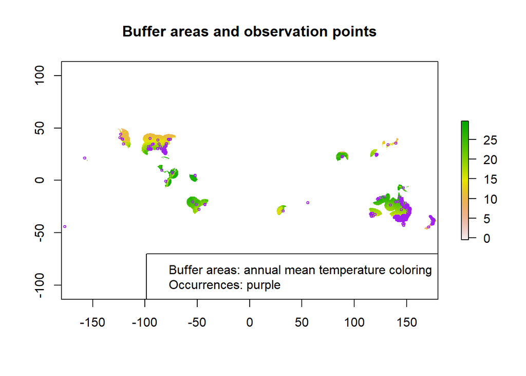

```r
occ_buff <- buffer(world_sampled,600000, dissolve=TRUE) #width parameter=600000m = 600km

# crop study area to buffer extent
studyArea <- crop(envs,extent(occ_buff))

# mask the non buffer areas
studyArea <- mask(studyArea,occ_buff)
# output will still be a raster stack, just of the study area

# check with plot
plot(studyArea[[1]]/10, main="Buffer areas and observation points")
points(world_sampled$lon, world_sampled$lat, pch=1, cex=0.51, col="purple")
legend("bottomright",legend=c("Buffer areas: annual mean temperature coloring",
                            "Occurrences: purple"))
```

### Randomly sample points

Sample same number as our observed points inside the buffer to create pseudo-absences, or hypothetical areas where species is not found

```r
set.seed(2020)
backg = randomPoints(studyArea, n=708, p=world_sampled, extf=1)
colnames(backg) <- c("lon","lat")
```

### Divide background dataset into training and testing

```r
group=kfold(backg, 5)
backg_train <- backg[group!=1,]
backg_test <- backg[group==1,]
```

### Run model and check variable contribution

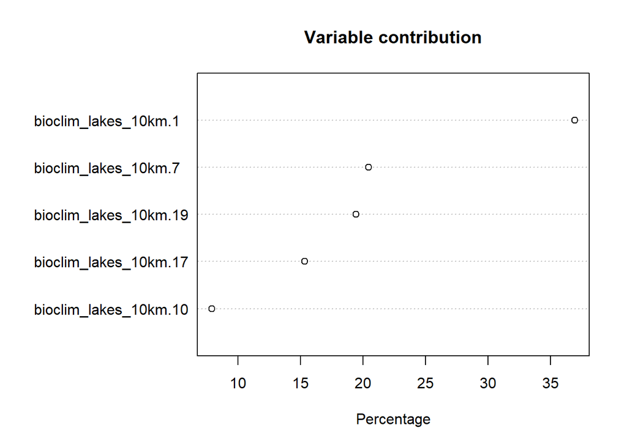

```r
xm <- maxent(modelEnv, pres_train, linear=true, quadratic=true, product=false,
              threshold=false, hinge=false)
plot(xm)

variable <- plot(xm)
```

```r
variable
```

```
## bioclim_lakes_10km.10 bioclim_lakes_10km.17 bioclim_lakes_10km.19
##                7.9037               15.3305               19.4100
##  bioclim_lakes_10km.7  bioclim_lakes_10km.1
##               20.4397               36.9159
```

### Check potential correlations between bioclimatic variables

| Preliminary variables | Variable contribution | Bioclimatic variables BIO1 | Bioclimatic variables BIO7 | Bioclimatic variables BIO19 | Bioclimatic variables BIO17 | Bioclimatic variables BIO10 |
| --- | --- | --- | --- | --- | --- | --- |
| BIO 1 (mean annual temperature) | 36.92 | 1 | -0.65 | 0.18 | 0.05 | 0.94 |
| BIO 7 (annual range of temperature) | 20.44 |  | 1.00 | -0.38 | -0.30 | -0.35 |
| BIO 19 (mean annual precipitation) | 19.41 |  |  | 1.00 | 0.80 | 0.07 |
| BIO17 (precipitation of driest quarter) | 15.33 |  |  |  | 1.00 | -0.05 |
| BIO 10 (mean temperature of the warmest quarter) | 7.90 |  |  |  |  | 1.00 |